# Statistical Inference Course Project 1

Avinash

October 25, 2015

# Overview

We investigate the exponential distribution in R and compare it with the Central Limit Theorem. The exponential distribution is simulated in R with rexp(n, lambda) where lambda is the rate parameter. The mean of exponential distribution is 1/lambda and the standard deviation is also 1/lambda. We set lambda = 0.2 for all of the simulation.We will investigate the distribution of averages of 40 exponentials over a thousand simulations.

### Simulation

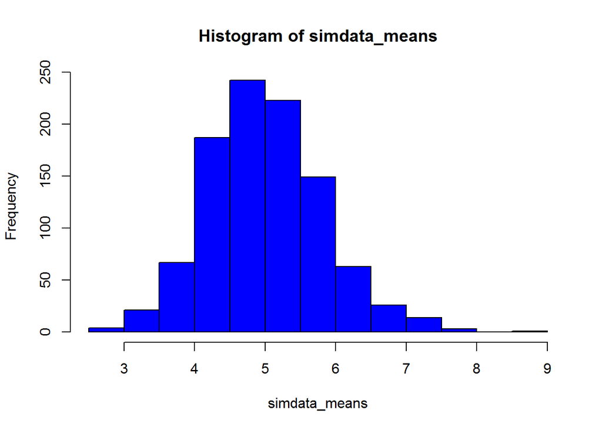

```r
library(ggplot2)
nosim <- 1000;
n <- 40;
lambda <- 0.2;
## create a matrix with 1000 simulations each with 40 rexp generated
## values
set.seed(234)
simdata <- matrix(rexp(nosim * n, rate=lambda), nosim);
## for each of the 1000 simulations calculate the average of across the
## 40 values
simdata_means <- apply(simdata, 1, mean);
hist(simdata_means, col="blue");
```

### Sample Mean versus Theoretical Mean

The expected mean $\mu$ of a exponential distribution of rate $\lambda$ is $\mu= \frac{1}{\lambda}$ Let $\bar X$ be the average sample mean of 1000 simulations of 40 randomly sampled exponential distributions. As you can see the expected mean and the avarage sample mean are very close

```r
theoretical_mean <- 1/lambda;
print (paste("Theoretical center of the distribution = ", theoretical_mean));
```

```
## [1] "Theoretical center of the distribution =  5"
```

```r
print (paste("Actual center of the distribution based on the simulations = ", round(mean(simdata_means), 3)));
```

```
## [1] "Actual center of the distribution based on the simulations =  5.002"
```